# Tutorial for pyjjasim

pyJJAsim is a circuit simulator for circuits that contain josephson junctions, aimed at large arrays and placing and visualizing Josephson vortices.

This notebook will show how to use it.

## Install pyjjasim

To install pyjjasim on any system, run:

```
pip install pyjjasim
```

from the command line, or run the cell below.

```python
import sys
!{sys.executable} -m pip install pyjjasim --upgrade
```

## First code; finding a static configuration

```
status:  0
result:  Static configuration with theta=[-6.32213147  0.23497196 -0.03894616  0.2752131   1.41371669 -6.0079722
 -0.2752131  -1.41371669 -0.2752131   0.03894616 -0.23497196  0.03894616
  0.03894616  6.0079722   6.55839841 -0.03894616 -0.23497196 -1.41371669
 -4.86946861  0.23497196  0.03894616 -0.2752131   0.2752131  -0.03894616]
newton iteration info: (tol=1e-10, maxiter=30)
	status: 0 (converged)
	number of iterations: 2
	residual: [6.29977989e-04 1.82883388e-08 8.07820107e-17]
	runtime (in sec): 0.0032989000000007707
```

```
(<Figure size 460.8x360 with 2 Axes>,
```

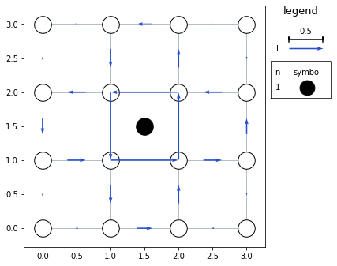

```python
from pyjjasim import *
%matplotlib inline
a = SquareArray(4, 4)
f = 0.1
n = [0, 0, 0, 0, 1, 0, 0, 0, 0]
problem = StaticProblem(a, frustration=f, vortex_configuration=n)
result, status, info = problem.compute()
print("status: ", status)
print("result: ", result)
print(info)
result.plot()
```

Now lets break down this example line by line.

```
from pyjjasim import *
```

Imports all functionality from pyjjasim, in this case the classes SquareArray and StaticProblem are used.

```
%matplotlib inline
```

Line only necessary in a Jupyter notebook to make sure the plot is shown.

```
a = SquareArray(4, 4)
```

Define a square array. Returns a Circuit object, where the circuit is a 4 by 4 square array.

```
f = 0.1
n = [0, 0, 0, 0, 1, 0, 0, 0, 0]
problem = StaticProblem(a, frustration=f, vortex_configuration=n)
```

Define the problem we are interested in. A StaticProblem needs a circuit, and optionally add several physical parameters, in this case frustration and a vortex configuration.

Frustration is an external magnetic flux through each face. There are 9 faces, but if the input is a scalar, the same flux is assumed to pass through each face.

The vortex configuration shows how many vortices are in each face. In this case a single vortex in the center face (how to know what index corresponds to what face is explained further on).

```
result, status, info = problem.compute()
```

Now we want to solve the problem! This is done with the compute() method. It returns the result, the status, and info. Here status is 0, 1 or 2. 0 means converged, 1 means diverged and 2 means indeterminate. info contains further information about the simulation.

The result is a StaticConfiguration object from which all information about the solution can be retrieved. Conveniently, one can use the .plot() method to visualize the result!

```
result.plot()
```

## Second code; running a time evolution

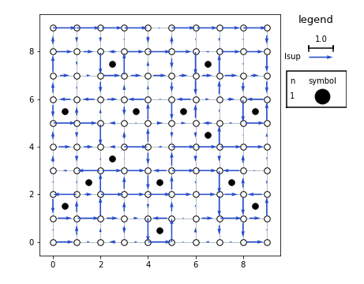

```python
%matplotlib notebook
sq_array = SquareArray(10, 10)
dt = 0.05
Nt = 1000
f = 0.2
Is = 0.5 * sq_array.current_base(angle=0)
T = 0.02
problem = TimeEvolutionProblem(sq_array, time_step=dt,
                               time_step_count=Nt, current_sources=Is,
                               frustration=f, temperature=T)
config = problem.compute()
config.animate(junction_quantity="supercurrent")
plt.show()
```

## Units

All quantities in pyJJAsim are dimensionless. This is done using three "free to choose" constants, I<sub>0</sub>, R<sub>0</sub> and a<sub>0</sub>, used to normalize currents, resistances and distances respectively. The normalizations for other quantities are:

| Quantity | Normalizing value | Equals |
| --- | --- | --- |
| Voltage | I<sub>0</sub> R<sub>0</sub> |  |
| Magnetic Flux | Phi<sub>0</sub> | h / 2*e |
| Energy | E<sub>J0</sub> | Phi<sub>0</sub> I<sub>0</sub> / 2*pi |
| Time | E<sub>J0</sub> / R<sub>0</sub> I<sub>0</sub><sup>2</sup> |  |
| Temperature | E<sub>J0</sub> / k<sub>B</sub> |  |
| Capacitance | E<sub>J0</sub> / R<sub>0</sub><sup>2</sup> I<sub>0</sub><sup>2</sup> |  |
| Inductance | E<sub>J0</sub> / I<sub>0</sub><sup>2</sup> |  |

# Josephson Junctions

A Josephson junction is an electrical component made using superconductors, acting as a non-linear inductor. Its current and voltage are as follows:

$I = I_c \sin{(\theta)}$

$V = \frac{1}{2\pi}\Phi_0 \frac{d\theta}{dt}$

1. The symbol for a Josephson junction is a cross.
2. $I_c$ is called the critical current of a junction and depends on geometry and material properties.
3. $\Phi_0=h/2e=2.067 \times 10^{-15}$Wb is the magnetic flux quantum.
4. Each junction has a quantity $\theta$ associated with it, called the gauge-invariant phase difference, encoding the state of the junction.
5. Josephson junctions are modelled with a resistor and capacitor in parallel. This is called the RCSJ model.

# Circuits

A Circuit consists of an EmbeddedGraph object (nodes connected by junctions), the physical properties (resistances, capacitances, inductances and critical currents) and the current-phase relation.

The embedded graph is a graph with nodes connected by junctions where no two junctions cross, so one can unambiguously speak of the "faces" of the graph. Every junction has the same prototype which looks as follows:

[figure not shown]

Here the values like resistance or capacitance can be set individually for each junction with an array of size junction_count.

1. If set to zero, the respective component is absent.
2. Inductance is defined by junction_count-sized square matrix so one can include coupling between junctions.
3. Sources are defined at a problem, not at a circuit (as in practice one often wants to vary them).
4. Critical currents, resistances, capacitances and inductances need not be specified, the default values are 1, 1, 0 and 0 respectively.

### Embedded graph

An embedded graph is defined by node coordinates (x, y) and a list of edges connecting node pairs (node1, node2). For example:

```
(<Figure size 360x360 with 1 Axes>, <AxesSubplot:>)
```

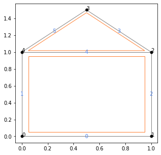

```python
%matplotlib inline
x = [0, 1, 1, 0.5, 0]
y = [0, 0, 1, 1.5, 1]
node1 = [0, 0, 1, 2, 2, 3]
node2 = [1, 4, 2, 3, 4, 4]
graph = EmbeddedGraph(x, y, node1, node2)
graph.plot(show_node_ids=True, show_edge_ids=True)
```

1. An embedded graph must be connected (so consisting of a single component).
2. No two junctions may cross so it is a planar embedding and one can speak unambiguously of faces.
3. The graph must be simple, so it may not have more than one edge between any two nodes and no edge starts and ends at the same node.
4. The number of nodes, junctions and faces can be extracted. They are also referred to with abbreviations in this tutorial.

| quantity | method for graph | method for circuit | abbreviation |
| --- | --- | --- | --- |
| node count | .node_count() | .node_count() | Nn |
| junction count | .edge_count() | .junction_count() | Nj |
| face count | .face_count() | .face_count() | Nf |

### Regular lattices

One can define three regular lattices: square arrays, honeycomb arrays and triangular arrays. They have Nx by Ny unit cells, by default the lattice constant is 1. One can stretch the arrays with scale factors ax and ay.

```
(<Figure size 648x504 with 4 Axes>,
```

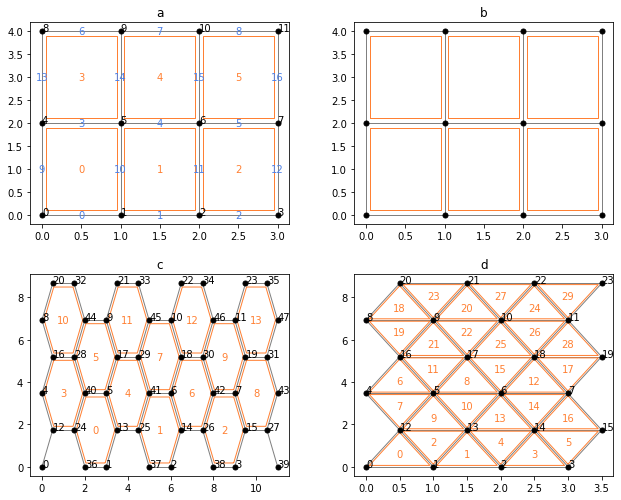

```python
Nx, Ny = 4, 3                                  # unit cell count
ax, ay = 1.0, 2.0                              # stretch factors
sq_array = SquareArray(Nx, Ny, ax, ay)         # Circuit object with R=1, Ic=1, L=0, C=0
sq_graph = EmbeddedSquareGraph(Nx, Ny, ax, ay) # EmbeddedGraph object
hc_array = HoneycombArray(Nx, Ny, ax, ay)
tr_array = TriangularArray(Nx, Ny, ax, ay)
fig, ax1 = sq_array.plot(show_junction_ids=True, ax_position=[0.05, 0.55, 0.4, 0.4],
                         figsize=[9, 7], title="a")
sq_graph.plot(fig=fig, ax_position=[0.55, 0.55, 0.4, 0.4], title="b")
hc_array.plot(fig=fig, ax_position=[0.05, 0.05, 0.4, 0.4], title="c")
tr_array.plot(fig=fig, ax_position=[0.55, 0.05, 0.4, 0.4], title="d")
```

One can set junction properties as follows:

```python
print(sq_array.get_resistance_factors())

sq_array.set_resistance_factors(2)
R = sq_array.get_resistance_factors()
print(R)

R[4] = 3
sq_array.set_resistance_factors(R)
print(sq_array.get_resistance_factors())
```

```
[1. 1. 1. 1. 1. 1. 1. 1. 1. 1. 1. 1. 1. 1. 1. 1. 1.]
[2 2 2 2 2 2 2 2 2 2 2 2 2 2 2 2 2]
[2 2 2 2 3 2 2 2 2 2 2 2 2 2 2 2 2]
```

### Faces

When creating an EmbeddedGraph object, the faces are computed automatically. Faces can host vortices and one can specify how much external magnetic flux passes through a face. One can retrieve information on faces as follows (both on EmbeddedGraph objects and Circuit objects):

```python
print("face count: ", sq_array.face_count())
print("face nodes: ", sq_array.get_faces())
print("face areas: ", sq_array.get_face_areas())
print("face centroids: ", sq_array.get_face_centroids())
```

```
face count:  6
face nodes:  [[0, 1, 5, 4], [1, 2, 6, 5], [2, 3, 7, 6], [4, 5, 9, 8], [5, 6, 10, 9], [6, 7, 11, 10]]
face areas:  [2. 2. 2. 2. 2. 2.]
face centroids:  (array([0.5, 1.5, 2.5, 0.5, 1.5, 2.5]), array([1., 1., 1., 3., 3., 3.]))
```

One can also locate faces as follows:

```python
xs = [0.2, 1.2]
ys = [5.4, 2.2]
print("nearest faces: ", sq_array.locate_faces(xs, ys))
```

```
nearest faces:  [3 4]
```

### Custom circuits

One can define a custom circuit with an embedded graph object as follows:

```
(<Figure size 432x288 with 1 Axes>, <AxesSubplot:>)
```

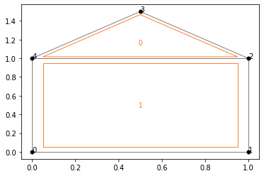

```python
circuit = Circuit(graph, resistance_factors=[1, 2, 3, 4, 5, 6])
circuit.plot()
```

# Static Problems

Current-biassed circuits with Josephson junctions have time-independent solutions. The have no dissipation and are called supercurrents. In pyJJAsim one can find such static solutions.

First one defines a StaticProblem object. This has the following properties:

| Property | Type |
| --- | --- |
| circuit | Circuit object |
| current_sources | (Nj,) array-like |
| frustration | (Nf,) array-like |
| vortex_configuration | (Nf,) array-like |
| initial_configuration | StaticConfiguration |

## Solutions to Static Problems: StaticConfiguration

One can find the solution of a static problem with the method problem.compute(). The result is a StaticConfiguration object. This has methods to extract information from the solution and to visualize it.

| Method | Description |
| --- | --- |
| get_theta() | returns a (Nj,) array with the theta value of each junction. |
| plot(...) | plots the solution on the circuit. One can specify what properties to show. |
| get_I() | returns a (Nj,) array with the current of through each junction. |
| get_n() | returns a (Nf,) int array with the vorticity of each face. |

If one knows $\theta$ for a static problem, one can manually create a static configuration:

```python
theta = [1.0, 2.0, 3.0, 4.0, 5.0, 6.0]
problem = StaticProblem(circuit)
config = StaticConfiguration(problem, theta)
print(config)
```

```
Static configuration with theta=[1. 2. 3. 4. 5. 6.]
```

## Frustration

Frustration is the external magnetic flux through each face of the circuit. Lets show some examples:

```
(<Figure size 720x324 with 3 Axes>,
```

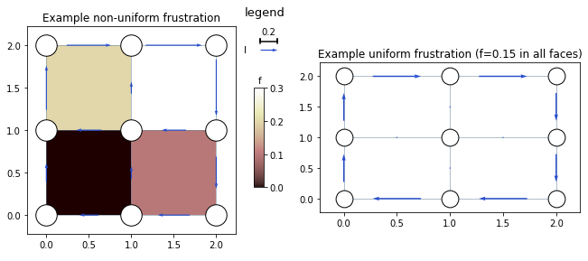

```python
%matplotlib inline

# example with non-uniform frustration
array = SquareArray(3, 3)
f1 = [0, 0.1, 0.2, 0.3] # external magnetic flux through each face
problem1 = StaticProblem(array, frustration=f1)
config1, status1, info1 = problem1.compute()
fig, _ = config1.plot(figsize=[10, 4.5], title="Example non-uniform frustration",
                      face_quantity=np.array(f1), axis_position=[0.1, 0.1, 0.4, 0.85],
                      manual_face_label="f")

# example with uniform frustration
f2 = 0.15 # external magnetic flux through each face
problem2 = StaticProblem(array, frustration=f2)
config2, status2, info2 = problem2.compute()
config2.plot(fig=fig, title="Example uniform frustration (f=0.15 in all faces)",
             axis_position=[0.55, 0.1, 0.4, 0.8], show_legend=False)
```

## Josephson vortices

One can define the property vortex_configuration in a static problem. This allows one to place Josephson vortices in the circuit. A Josephson vortex is assigned to a face, and it is represented by its vorticity, which is an integer. It counts the number of vortices in that face, and if it is negative, it counts the number of anti-vortices. The vortex_configuration is an (Nf,) int array with the vorticity of each face.

This vorticity is fundamentally the winding number of the order parameter, and looks like a swirling current. It also behaves as a charged particle, where nearby vortices repel eachother, but a vortex attracts an anti-vortex.

Lets show some examples:

```
newton iteration info: (tol=1e-10, maxiter=30)
	status: 0 (converged)
	number of iterations: 3
	residual: [2.18318652e-02 1.26381196e-04 4.48830761e-09 1.71251380e-15]
	runtime (in sec): 0.005023899999969217
newton iteration info: (tol=1e-10, maxiter=30)
	status: 0 (converged)
	number of iterations: 3
	residual: [2.18318652e-02 1.26381196e-04 4.48830761e-09 1.71251380e-15]
	runtime (in sec): 0.0026962999999682324
newton iteration info: (tol=1e-10, maxiter=30)
	status: 0 (converged)
	number of iterations: 2
	residual: [5.13129542e-03 1.91116664e-06 2.59151451e-13]
	runtime (in sec): 0.001851199999975961
newton iteration info: (tol=1e-10, maxiter=30)
	status: 0 (converged)
	number of iterations: 3
	residual: [1.81790109e-02 7.09587647e-04 1.28646833e-06 4.26047236e-12]
	runtime (in sec): 0.002678699999876244
newton iteration info: (tol=1e-10, maxiter=30)
	status: 1 (diverged)
	number of iterations: 7
	residual: [1.93871869e-01 5.67695620e-02 1.30948213e-01 5.07504800e-02
 2.87985728e-02 2.61750263e-04 1.79498358e-08 2.20462790e-16]
	runtime (in sec): 0.005876199999988785
newton iteration info: (tol=1e-10, maxiter=30)
	status: 1 (diverged)
	number of iterations: 4
	residual: [0.16685134 0.36261085 0.35566088 0.31352512 0.31245979]
	runtime (in sec): 0.003472900000019763
newton iteration info: (tol=1e-10, maxiter=30)
	status: 0 (converged)
	number of iterations: 3
	residual: [3.55246241e-02 2.11599916e-04 6.00282435e-09 2.77275899e-16]
	runtime (in sec): 0.0026684999999702086
newton iteration info: (tol=1e-10, maxiter=30)
	status: 0 (converged)
	number of iterations: 3
	residual: [2.18318652e-02 1.26381196e-04 4.48830772e-09 7.80849187e-16]
	runtime (in sec): 0.0026955999999813685
```

```
(<Figure size 720x504 with 6 Axes>,
```

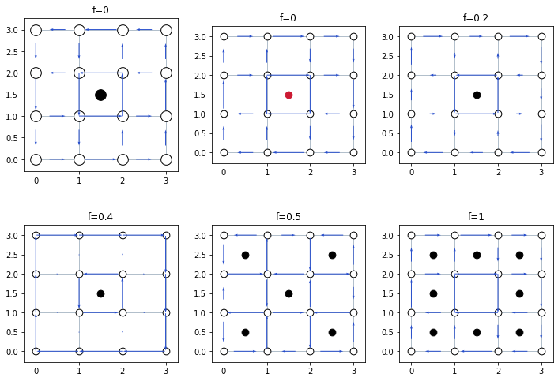

```python
%matplotlib inline

from pyjjasim import *

array = SquareArray(4, 4)
n1 = [0, 0, 0, 0, 1, 0, 0, 0, 0] # vorticity of each face
n2 = [0, 0, 0, 0, -1, 0, 0, 0, 0] # vorticity of each face
n3 = [0, 0, 0, 0, 1, 0, 0, 0, 1] # vorticity of each face
n4 = [1, 0, 1, 0, 1, 0, 1, 0, 1] # vorticity of each face
n5 = [1, 1, 1, 1, 0, 1, 1, 1, 1] # vorticity of each face

problem1 = StaticProblem(array, vortex_configuration=n1)
config1, status, info = problem1.compute()
print(info)

fig, ax11 = config1.plot(figsize=[10, 7], axis_position=[0.05, 0.55, 0.27, 0.4],
                         show_legend=False, title="f=0")

problem2 = StaticProblem(array, vortex_configuration=n2)
config2, status, info = problem2.compute()
print(info)
fig, ax12 = config2.plot(fig=fig, axis_position=[0.38, 0.55, 0.27, 0.4],
                         show_legend=False, title="f=0")

problem3 = StaticProblem(array, vortex_configuration=n1, frustration=0.2)
config3, status, info = problem3.compute()
print(info)
fig, ax13 = config3.plot(fig=fig, axis_position=[0.71, 0.55, 0.27, 0.4],
                         show_legend=False, title="f=0.2")

problem4 = StaticProblem(array, vortex_configuration=n1, frustration=0.4)
config4, status, info = problem4.compute()
print(info)
fig, ax21 = config4.plot(fig=fig, axis_position=[0.05, 0.05, 0.27, 0.4],
                         show_legend=False, title="f=0.4")

problem5 = StaticProblem(array, vortex_configuration=n1, frustration=0.6)
config5, status, info = problem5.compute()
print(info) # does not converge, no solution exists!

problem6 = StaticProblem(array, vortex_configuration=n3)
config6, status, info = problem6.compute()
print(info) # does not converge, no solution exists!

problem = StaticProblem(array, vortex_configuration=n4, frustration=0.5)
config, status, info = problem.compute()
print(info)
config.plot(fig=fig, axis_position=[0.38, 0.05, 0.27, 0.4], show_legend=False, title="f=0.5")

problem = StaticProblem(array, vortex_configuration=n5, frustration=1.0)
config, status, info = problem.compute()
print(info)
config.plot(fig=fig, axis_position=[0.71, 0.05, 0.27, 0.4], show_legend=False, title="f=1")
```

Some lessons to be learned:

1. Not all vortex configurations have solutions. Static configurations are only possible if the forces are small enough so that vortices are not de-pinned.
2. Vortices must be spread out.
3. the mean number of vortices can not deviate too much from the mean frustration.

If one wants to place a vortex at a location, one needs to know which face corresponds to that location. This is shown with the next example.

```
(<Figure size 360x360 with 2 Axes>,
```

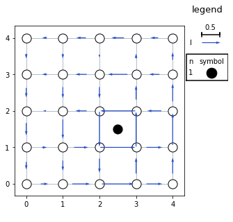

```python
array = SquareArray(5, 5)
n = np.zeros(array.face_count(), dtype=int)
n[array.locate_faces(2.5, 1.5)] = 1
problem = StaticProblem(array, vortex_configuration=n)
config, _, _ = problem.compute()
config.plot(figsize=[5, 5])
```

## Current sources

One can specify current sources at each junction. Alternatively, one can also think of current injected/ejected at each node. Such node-current as source can be achieved by converting it into junction-sources with the method node_to_junction_current. For example:

```
(<Figure size 460.8x360 with 2 Axes>,
```

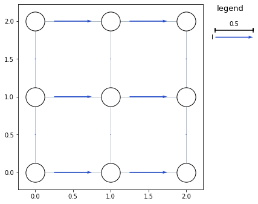

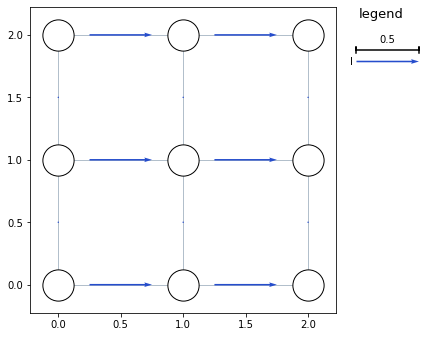

```python
array = SquareArray(3, 3)
I_source_junc = 0.5 * np.array([1, 1, 1, 1, 1, 1, 0, 0, 0, 0, 0, 0])
prob1 = StaticProblem(array, current_sources=I_source_junc)
config1, _, _ = prob1.compute()
config1.plot()

I_source_node = 0.5 * np.array([1, 0, -1, 1, 0, -1, 1, 0, -1])
converted_I_source = node_to_junction_current(array, I_source_node)
prob2 = StaticProblem(array, current_sources=converted_I_source)
config2, _, _ = prob2.compute()
config2.plot()
```

The lattices have a convenient method to allow one to setup a current at a specified angle:

```
(<Figure size 460.8x360 with 2 Axes>,
```

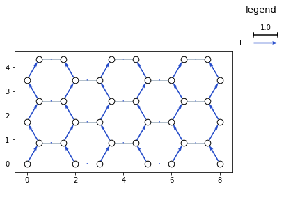

```python
array = HoneycombArray(3, 3)
I_source = 0.5 * array.current_base(angle=np.pi/2)
prob = StaticProblem(array, current_sources=I_source)
config, _, _ = prob.compute()
config.plot()
```

## Maximize parameters

pyJJAsim provides methods to find the largest value of a parameter for which a static configuration exists. These are:

1. compute_frustration_bounds(...) to compute minimum and maximum frustration
2. compute_maximal_current(...) to compute maximal current source
3. compute_stable_region(angles, ...) to compute stable region in (frustration-current) space

For example, prob.compute_frustration_bounds() takes the frustration value of prob f=prob.get_frustration() and finds the extreme values of x for frustration = x * f for which prob has a static configuration.

```
(<Figure size 720x324 with 3 Axes>,
```

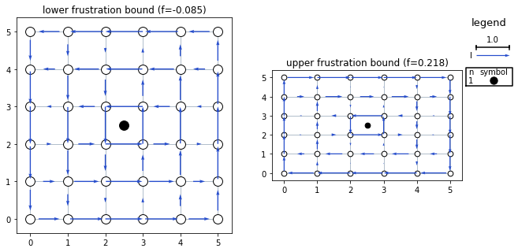

```python
# example for frustration bounds
array = SquareArray(6, 6)
n = np.zeros(array.face_count(), dtype=int)
n[array.locate_faces(2.5, 2.5)] = 1
problem = StaticProblem(array, vortex_configuration=n, frustration=1)
bounds, configs, infos = problem.compute_frustration_bounds()

# plotting
fig, _ = configs[0].plot(figsize=[10, 4.5], title=f"lower frustration bound (f={bounds[0]:.3f})",
                        axis_position=[0.1, 0.1, 0.38, 0.85], show_legend=False)
configs[1].plot(fig=fig, title=f"upper frustration bound (f={bounds[1]:.3f})",
               axis_position=[0.55, 0.1, 0.42, 0.85])
```

```
(<Figure size 360x360 with 2 Axes>,
```

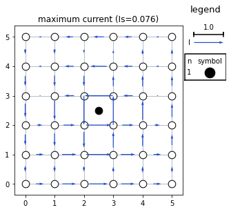

```python
# example for maximum current sources
array = SquareArray(6, 6)
n = np.zeros(array.face_count(), dtype=int)
n[array.locate_faces(2.5, 2.5)] = 1
Is = array.current_base(angle=0)
problem = StaticProblem(array, vortex_configuration=n, current_sources=Is)
I_factor, config, info = problem.compute_maximal_current()
config.plot(figsize=[5, 5], title=f"maximum current (Is={I_factor:.3f})")
```

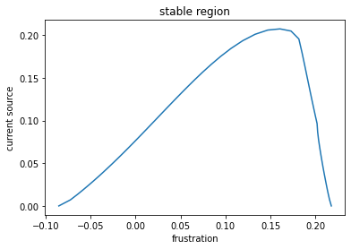

```python
# example for whole stable region in f-Is space
array = SquareArray(6, 6)
n = np.zeros(array.face_count(), dtype=int)
n[array.locate_faces(2.5, 2.5)] = 1
Is = array.current_base(angle=0)
problem = StaticProblem(array, vortex_configuration=n, current_sources=Is, frustration=1)
angles = np.linspace(0, np.pi, 61)
f, I, configs, infos = problem.compute_stable_region(angles=angles)
plt.plot(f, I)
plt.xlabel("frustration")
plt.ylabel("current source")
plt.title("stable region")
```

## Approximations and initial guesses

To compute a static configuration, one needs an initial guess. If this is not provided, an approximation is used as an initial guess. In pyJJAsim, two algorithms can be used to find an approximate solution to an static_problem, called the arctan approximation (algorithm=0) or the london approximation (algorithm=1, default). For example:

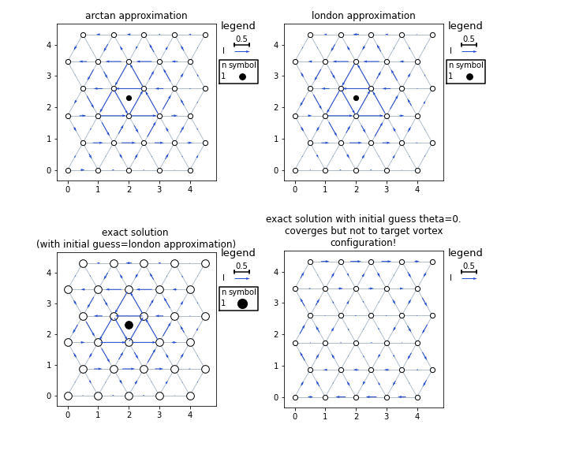

```
exact satisfies target n?:  True
arctan_approx is solution?: False, error: (0.09797852724409971, 2.824476894750778e-17)
london_approx is solution?: False, error: (0.004750681981079487, 3.920202629476347e-17)
exact is solution?: True, error: (1.5919840397399833e-16, 4.0032686880764e-17)
exact2 satisfies target n?:  False
```

```python
array = TriangularArray(5, 3)
f = 0.02
n1 = np.zeros(array.face_count(), dtype=int)
n2 = np.zeros(array.face_count(), dtype=int)
n2[array.locate_faces(2, 2)] = 1
prob1 = StaticProblem(array, frustration=f, vortex_configuration=n1)
prob2 = StaticProblem(array, frustration=f, vortex_configuration=n2)

# the instruction:
exact, _, _ = prob2.compute()

# does under the hood:
approx = prob2.approximate(algorithm=1)
exact, _, _ = prob2.compute(approx)

fig, _ = exact.plot(title="exact solution \n(with initial guess=london approximation)",
                    axis_position=[0.1, 0.1, 0.35, 0.35], figsize=[10, 8])
print("exact satisfies target n?: ", exact.satisfies_target_vortices()) # -> True

arctan_approx = prob2.approximate(algorithm=0)
london_approx = prob2.approximate(algorithm=1)
arctan_approx.plot(title="arctan approximation", fig=fig, axis_position=[0.1, 0.6, 0.35, 0.35])
london_approx.plot(title="london approximation", fig=fig, axis_position=[0.5, 0.6, 0.35, 0.35])
print(f"arctan_approx is solution?: {arctan_approx.is_solution()},
      error: {arctan_approx.get_error()}")
print(f"london_approx is solution?: {london_approx.is_solution()},
      error: {london_approx.get_error()}")
print(f"exact is solution?: {exact.is_solution()}, error: {exact.get_error()}")


# manual initial guess
theta_init_guess = np.zeros(array.junction_count())
exact2, _, _ = prob2.compute(theta_init_guess)
exact2.plot(title="exact solution with initial guess theta=0.\n" \
            "coverges but not to target vortex\nconfiguration!", fig=fig,
            axis_position=[0.5, 0.1, 0.35, 0.35])
print("exact2 satisfies target n?: ", exact2.satisfies_target_vortices()) # -> False
```

## Dynamic Stability

A static configuration may not be dynamically stable, even if it is a valid solution. This can be tested with .is_stable(). Also in parameter optimizations one can specify if stability is required. All previous examples were stable, here an example of an unstable configuration is shown with a vortex placed on a junction. This is done with the .approximate_placed_vortices(...) method.

```
config 1 solution properties:
Kirchhoff rules error:     5.790050225601533e-17
Path rules error:          4.137202557650179e-17
is stable:                 True
is target vortex solution: False
config 2 solution properties:
Kirchhoff rules error:     9.369033515465136e-11
Path rules error:          1.832401386169336e-17
is stable:                 False
is target vortex solution: False
config2 stable status:  0
```

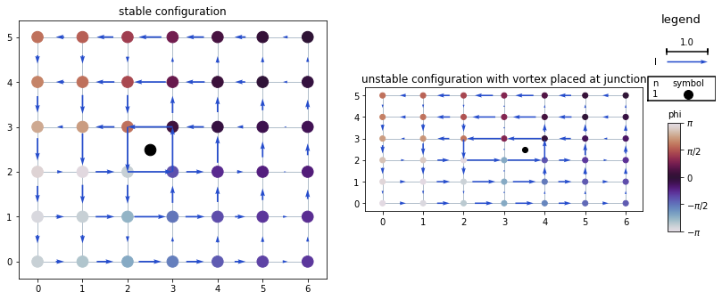

```python
array = SquareArray(7, 6)
prob = StaticProblem(array)
approx1 = prob.approximate_placed_vortices([1], [2.5], [2.5])
approx2 = prob.approximate_placed_vortices([1], [3], [2.5])
config1, _, _ = prob.compute(approx1)
config2, _, _ = prob.compute(approx2)
fig, _ = config1.plot(node_quantity="phi", title="stable configuration", figsize=[12, 5],
                      axis_position=[0.05, 0.1, 0.4, 0.85], show_legend=False)
config2.plot(node_quantity="phi", title="unstable configuration with vortex placed at junction",
             fig=fig, axis_position=[0.5, 0.1, 0.45, 0.85],)
print("config 1 solution properties: ")
config1.report()
print("config 2 solution properties: ")
config2.report()
stable_status = config1.is_stable() # status 0 -> stable, 1-> unstable, 2-> indeterminate
print("config2 stable status: ", stable_status)
```

1. In the last example the vortex is not shown at the junction. This is because a vortex is formally a property of a single face. In this case the rounding determines in which face is is shown.
2. The node colors represent the phase $\phi$ of the superconducting order parameter. The phase along any closed loop through the array winds exactly $2 \pi$ times the number of enclosed vortices.
3. If no magnetic field is present, $\theta$ of a junction is the difference between the phases $\phi$ at its endpoints.

## Vortices in screened arrays

So far inductance has been neglected. If one includes inductance, the currents generate magnetic flux. If the inductance is large, each face will have a magnetic flux through it equal to its vorticity times the flux quantum $\Phi_0$ (called flux quantization). If an array has inductance, it is called a screened array. Vortices in screened arrays are much more stable, and so it is much easier to find stationairy states.

```
newton iteration info: (tol=1e-10, maxiter=30)
	status: 1 (diverged)
	number of iterations: 4
	residual: [2.35702260e-01 2.34307160e-01 2.35680432e-01 4.57773331e-03
 4.55899255e-11]
	runtime (in sec): 0.004408500002682558
newton iteration info: (tol=1e-10, maxiter=30)
	status: 0 (converged)
	number of iterations: 4
	residual: [4.89206057e-02 4.49052183e-03 3.78619241e-05 3.01677892e-09
 8.71198474e-17]
	runtime (in sec): 0.003380799998922157
```

```
(<Figure size 720x576 with 8 Axes>,
```

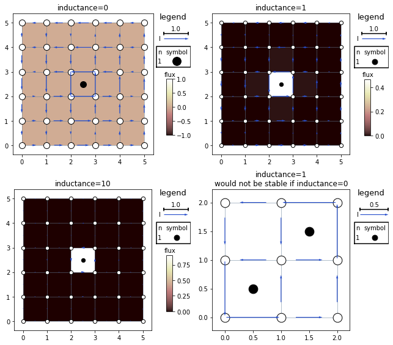

```python
# Flux quantization
array = SquareArray(6, 6)
n = np.zeros(array.face_count())
n[array.locate_faces(2.5, 2.5)] = 1
config_no_L, _, _ = StaticProblem(array, vortex_configuration=n).compute()
fig, _ = config_no_L.plot(face_quantity="Phi", title="inductance=0", figsize=[10, 8],
                          axis_position=[0.1, 0.55, 0.4, 0.4], face_quantity_clim=[-1, 1])
array.set_inductance_factors(1) # all junctions get inductor with L=1
config_L1, _, _ = StaticProblem(array, vortex_configuration=n).compute()
config_L1.plot(face_quantity="Phi", title="inductance=1", fig=fig,
               axis_position=[0.55, 0.55, 0.4, 0.4])
array.set_inductance_factors(10)
config_L10, _, _ = StaticProblem(array, vortex_configuration=n).compute()
config_L10.plot(face_quantity="Phi", title="inductance=10", fig=fig,
               axis_position=[0.1, 0.05, 0.4, 0.4])

# It is easier to find static configurations in screened arrays
array = SquareArray(3, 3)
config_no_L, _, info_no_L = StaticProblem(array, vortex_configuration=[1, 0, 0, 1]).compute()
array.set_inductance_factors(1)
config_with_L, _, info_with_L = StaticProblem(array, vortex_configuration=[1, 0, 0, 1]).compute()

print(info_no_L)
print(info_with_L)
config_with_L.plot(fig=fig, axis_position=[0.55, 0.05, 0.4, 0.4],
                   title="inductance=1\nwould not be stable if inductance=0")
```

# Time evolutions

The second type of problems pyJJAsim can solve is time-evolutions. The time evolutions is in steps of fixed size. One can specify the time_step dt and the number of steps Nt. Note that time is dimensionless (see Units section).

One can control the following physical parameters:

1. Current sources at each junction. Numpy array shape: (Nj, W, Nt)
2. Voltage sources at each junction. Numpy array shape: (Nj, W, Nt)
3. External magnetic flux through each face (frustration). Numpy array shape: (Nf, W, Nt)
4. Temperature of each junction. Numpy array shape: (Nj, W, Nt)

These must be specified as numpy arrays that are broadcast-compatible (Look up numpy broadcasting rules if this is new to you). Because of this setup, multiple time evolution problems can be specified at once, where W is the problem_count. The reason is that one often wants this (for example an IV curve), and it is computationally faster to do them simultaneously.

Some notes:

1. Temperature is modelled as thermal fluctuations in the resistors.
2. One can specify one or two initial conditions. Two are only needed if any capacitor is present.
3. One cannot explicitly specify vortices, they are implicitly present in the initial condition(s).

Below three examples are shown where frustration, temperature and current are sweeped respectively.

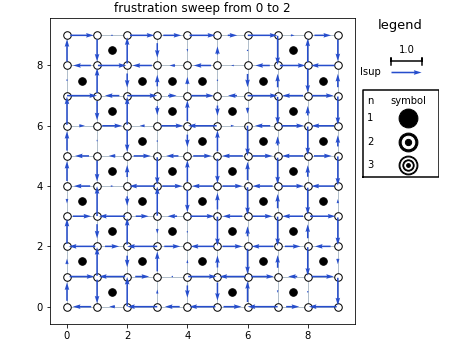

```python
%matplotlib notebook
# Example of sweeping the frustration factor
sq_array = SquareArray(10, 10)
Nt = 3000
f = np.linspace(0, 2, Nt)[None, None, :]
problem = TimeEvolutionProblem(sq_array, time_step=0.05, time_step_count=Nt,
                               frustration=f, temperature=0.02)
config = problem.compute()
config.animate(junction_quantity="supercurrent", title="frustration sweep from 0 to 2")
plt.show()
```

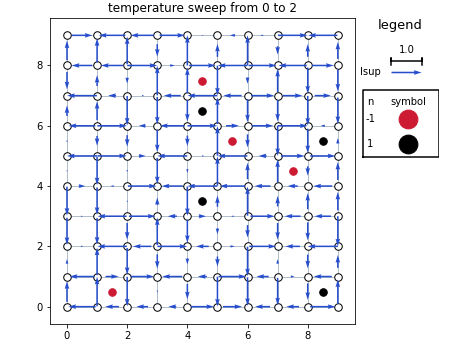

```python
# Example of sweeping temperature
sq_array = SquareArray(10, 10)
Nt = 3000
T = np.linspace(0, 2, Nt)[None, None, :]
problem = TimeEvolutionProblem(sq_array, time_step=0.05, time_step_count=Nt,
                               temperature=T)
config = problem.compute()
config.animate(junction_quantity="supercurrent", title="temperature sweep from 0 to 2")
plt.show()
```

[figure not shown]

```python
# Example of sweeping current
sq_array = SquareArray(10, 10)
Nt = 3000
I_base = sq_array.current_base(angle=0)
I = I_base[:, None, None] * np.linspace(0, 2, Nt)
problem = TimeEvolutionProblem(sq_array, time_step=0.05, time_step_count=Nt,
                               temperature=0.02, current_sources=I)
config = problem.compute()
config.animate(junction_quantity="supercurrent", title="current sweep from 0 to 2")
plt.show()
```

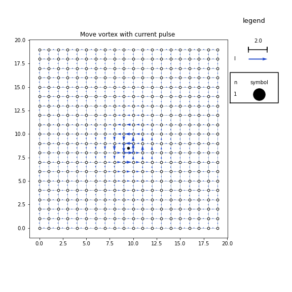

```
(<Figure size 576x576 with 2 Axes>,
```

```python
# example of current pulse
%matplotlib notebook
from scipy.stats import norm
sq_array = SquareArray(20, 20)
dt = 0.05
Nt = 2000
ts = np.arange(0, Nt, 3)
Ih = sq_array.current_base(angle=0)
amp = 2
Is = amp * Ih[:, None, None] * norm(loc=30, scale=1.0).pdf(np.arange(Nt) * dt)
n = np.zeros(sq_array.face_count(), dtype=int)
n[sq_array.locate_faces(19/ 2, 19/2)] = 1
init, _, _ = StaticProblem(sq_array, vortex_configuration=n).compute()
init_th = init.get_theta()[:, None]

problem = TimeEvolutionProblem(sq_array, time_step=dt, time_step_count=Nt, current_sources=Is,
                               store_time_steps=ts, config_at_minus_1=init_th)
out = problem.compute()
out.animate(figsize=(8, 8), title="Move vortex with current pulse ")
```

## IV curves

To compute IV curves, one can either ramp the current as a function of time, or compute multiple problems with constant current. Both are shown:

```
(10000,)
```

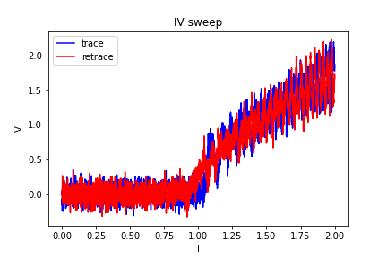

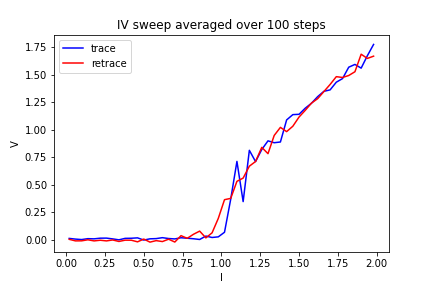

```python
# Example of sweeping current
sq_array = SquareArray(10, 10)
Nt = 10000
I_base = sq_array.current_base(angle=0)[:, None, None]
I_amp = np.append(np.linspace(0, 2, Nt//2), np.linspace(2, 0, Nt//2))
I = I_base * I_amp
problem = TimeEvolutionProblem(sq_array, time_step=0.05, time_step_count=Nt,
                               temperature=0.02, current_sources=I)
config = problem.compute()
V = config.get_V()
Vmean = 2 * np.mean(V * I_base, axis=0).ravel()
print(Vmean.shape)
plt.subplots()
plt.plot(I_amp[:Nt//2], Vmean[:Nt//2], color="blue", label="trace")
plt.plot(I_amp[Nt//2:], Vmean[Nt//2:], color="red", label="retrace")
plt.xlabel("I")
plt.ylabel("V")
plt.title("IV sweep")
plt.legend()

# Now average over 100 consecutive steps
plt.subplots()
I_amp_av = np.mean(np.reshape(I_amp, (-1, 100)), axis=1)
Vmean_av = np.mean(np.reshape(Vmean, (-1, 100)), axis=1)
plt.plot(I_amp_av[:Nt//200], Vmean_av[:Nt//200], color="blue", label="trace")
plt.plot(I_amp_av[Nt//200:], Vmean_av[Nt//200:], color="red", label="retrace")
plt.xlabel("I")
plt.ylabel("V")
plt.title("IV sweep averaged over 100 steps")
plt.legend()
```

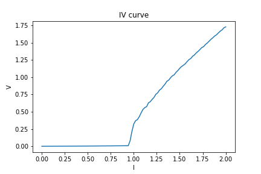

```python
# Example of IV curve
sq_array = SquareArray(10, 10)
Nt = 3000
T = 0.02
f = 0
W = 101 # problem count
I_base = sq_array.current_base(angle=0)[:, None, None]
I_amp = np.linspace(0, 2, W)[:, None]
I = I_base * I_amp
problem = TimeEvolutionProblem(sq_array, time_step=0.05, time_step_count=Nt,
                               temperature=T, current_sources=I, frustration=f)
config = problem.compute()
V = config.get_V()
Vmean = 2 * np.mean(V * I_base, axis=(0, 2)).ravel()
plt.subplots()
plt.plot(I_amp[:, 0], Vmean)
plt.xlabel("I")
plt.ylabel("V")
plt.title("IV curve")
```

The start conditions can also be specified with config_at_minus_1 (and config_at_minus_2 if any capacitance is present). By default it is set to $\theta = 0$ for all junctions.

Under some circumstances the voltage of an array can be metastable between zero and some value. In this case the initial conditions determine in which state one ends up. This is illustrated below by starting with a very random initial condition, far out-of-equilibrium.

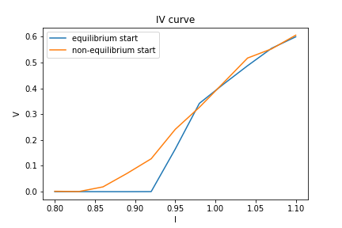

```python
# Example of IV curve with out-of-equilibrium start conditions
sq_array = SquareArray(30, 30)
Nt = 2000
dt = 0.1
T = 0.02
f = 0
W = 11 # problem count
I_base = sq_array.current_base(angle=0)[:, None, None]
I_amp = np.linspace(0.8, 1.1, W)[:, None]
I = I_base * I_amp

# equilibrium start
problem_eq = TimeEvolutionProblem(sq_array, time_step=dt, time_step_count=Nt,
                               temperature=T, current_sources=I, frustration=f)
config_eq = problem_eq.compute()
V_eq = config_eq.get_V()
# take mean over second half of time evolution
Vmean_eq = 2 * np.mean(V_eq[:, :, Nt//2:] * I_base, axis=(0, 2)).ravel()

# non-equilibrium start
th0 = 100 * np.random.rand(sq_array.junction_count(), W)
problem_neq = TimeEvolutionProblem(sq_array, time_step=dt, time_step_count=Nt,
                               temperature=T, current_sources=I, frustration=f,
                               config_at_minus_1=th0)
config_neq = problem_neq.compute()
V_neq = config_neq.get_V()
# take mean over second half of time evolution
Vmean_neq = 2 * np.mean(V_neq[:, :, Nt//2:] * I_base, axis=(0, 2)).ravel()

plt.subplots()
plt.plot(I_amp[:, 0], Vmean_eq, label="equilibrium start")
plt.plot(I_amp[:, 0], Vmean_neq, label="non-equilibrium start")
plt.xlabel("I")
plt.ylabel("V")
plt.legend()
plt.title("IV curve")

# TLDR: start conditions can matter (generally only if T is small and/or V is small)
```

## Shapiro steps

Shapiro steps are plateaus in the voltage over a range of DC current caused by an AC component in the external current. Here is an example where Is = IDC + IAmp *sin(Ifreq* t).

Here an alternative way to specify current sources is used. Rather than a numpy array broadcastable to the shape (Nj, W, Nt), one can specify a function with the timestep i as input and an (Nj, W) shaped numpy array as output (or broadcastable to (Nj, W)). This can save memory.

Also, one can control what data is stored during the time-evolution simulation. One can specify what time-points are stored with store_time_steps. Furthermore by default theta, I and V are stored during simulation, but one can manually disable one of these for example by setting store_current=False.

Note that if one wants to query for example the magnetic flux from the result, this will result in an error as this requires the current to be stored.

Lastly, the mean voltage is computed using $V = \frac{d\theta}{dt}$ (in the normalized units).

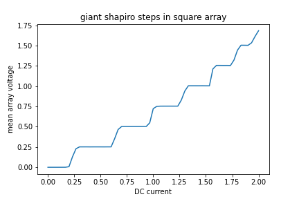

```python
# define array
N = 20
sq_array = SquareArray(N, N)

# define problem
T = 0.01
dt = 0.1
Nt = 3000
ts = [Nt//3, Nt - 1]

IAmp = 1
Ifreq = 0.25
IDC = np.linspace(0, 2, 61)
Is = lambda i: sq_array.current_base(angle=0)[:, None] * (IDC + np.sin(Ifreq * i * dt))

prob = TimeEvolutionProblem(sq_array, time_step=dt, time_step_count=Nt,
                            current_sources=Is, temperature=T, store_time_steps=ts,
                            store_theta=True, store_current=False, store_voltage=False)

# do time simulation
out = prob.compute()

# compute array voltage
th = out.get_theta()[sq_array.current_base(angle=0)==1, :, :]
th_at_one_third = th[:, :, 0]
last_th = th[:, :, 1]
V = np.mean((last_th - th_at_one_third) / (dt * (ts[1] - ts[0])), axis=0)

# plot array voltage
plt.subplots()
plt.plot(IDC, V, label='f=0')
plt.xlabel("DC current")
plt.ylabel("mean array voltage")
plt.title("giant shapiro steps in square array")
plt.show()
```

## Annealing

Annealing is doing a time evolution with gradually decreasing temperature. The goal of this is to find a state with a low energy (with vortices "perfectly" spread out).

A annealing problem can be specified with AnnealingProblem(). One does not need to specify the temperature profile. Rather; one specifies the target vortex_mobility. The vortex mobility is measured during the time evolution and if this exceeds the target, the temperature is lowered. The target vortex mobility goes from vortex_mobility at t=0 to 0 at the last timestep.

The vortex mobility is measured over an interval of interval_steps timesteps. After each interval the tempeture is updated (by multiplying with- or dividing by T_factor). A total of interval_count intervals are computed.

One can compute multiple identical problems with problem_count. Typically one selects the result with the lowest energy as shown in the example.

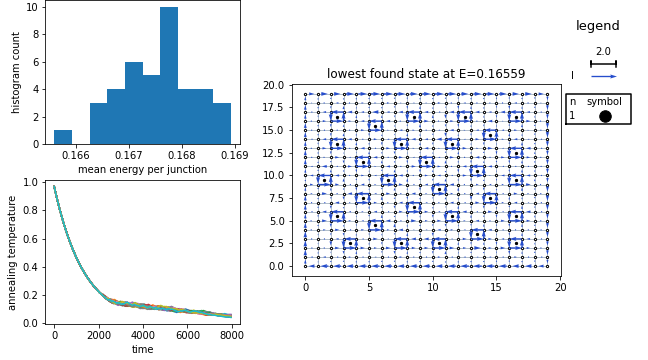

```python
# Example of annealing
sq_array = SquareArray(20, 20)
f = 0.1
time_step = 2.0
interval_steps = 20
interval_count = 200
vortex_mobility = 0.001
problem_count = 40
start_T = 1.0
T_factor = 1.03
problem = AnnealingProblem(sq_array, time_step=time_step, interval_steps=interval_steps,
                           interval_count=interval_count, vortex_mobility=vortex_mobility,
                           frustration=f, problem_count=problem_count,
                           start_T=start_T, T_factor=T_factor)
# do time simulation
out = problem.compute()
status, vortex_configurations, temperature_profiles = out

energies = [np.mean(v.get_Etot()) for v in vortex_configurations]
lowest_state = np.argmin(energies)

fig = plt.figure(figsize=[9, 5])
a1 = fig.add_axes([0.07, 0.6, 0.3, 0.4])
a1.hist(energies)
a1.set_xlabel("mean energy per junction")
a1.set_ylabel("histogram count")

# plot temperature evolution
a2 = fig.add_axes([0.07, 0.1, 0.3, 0.4])
a2.plot(time_step * interval_steps * np.arange(interval_count), temperature_profiles)
a2.set_xlabel("time")
a2.set_ylabel("annealing temperature")

lowest_E = energies[lowest_state]
vortex_configurations[lowest_state].plot(fig=fig, axis_position=[0.45, 0.05, 0.52, 0.9],
                                         title=f"lowest found state at E={lowest_E:.5f}")
plt.show()
```